# Risk Factor Analysis

## Outcome Variable

**Outcome Variable:** pers_wast

## Predictor Variables

**Intervention Variable:** hdlvry

**Adjustment Set:**

- arm
- sex
- W_mage
- meducyrs
- feducyrs
- hhwealth_quart
- W_nrooms
- brthmon
- W_parity
- impsan
- delta_W_mage
- delta_meducyrs
- delta_feducyrs
- delta_hhwealth_quart
- delta_W_nrooms
- delta_brthmon
- delta_W_parity
- delta_impsan

## Stratifying Variables

The analysis was stratified on these variable(s):

- agecat
- studyid
- country

## Data Summary

| agecat | studyid | country | hdlvry | pers_wast | n_cell | n |
| --- | --- | --- | --- | --- | --- | --- |
| 0-24 months | ki1000108-CMC-V-BCS-2002 | INDIA | 0 | 0 | 339 | 370 |
| 0-24 months | ki1000108-CMC-V-BCS-2002 | INDIA | 0 | 1 | 23 | 370 |
| 0-24 months | ki1000108-CMC-V-BCS-2002 | INDIA | 1 | 0 | 8 | 370 |
| 0-24 months | ki1000108-CMC-V-BCS-2002 | INDIA | 1 | 1 | 0 | 370 |
| 0-24 months | ki1000108-IRC | INDIA | 0 | 0 | 354 | 410 |
| 0-24 months | ki1000108-IRC | INDIA | 0 | 1 | 48 | 410 |
| 0-24 months | ki1000108-IRC | INDIA | 1 | 0 | 8 | 410 |
| 0-24 months | ki1000108-IRC | INDIA | 1 | 1 | 0 | 410 |
| 0-24 months | ki1000109-EE | PAKISTAN | 0 | 0 | 235 | 375 |
| 0-24 months | ki1000109-EE | PAKISTAN | 0 | 1 | 17 | 375 |
| 0-24 months | ki1000109-EE | PAKISTAN | 1 | 0 | 113 | 375 |
| 0-24 months | ki1000109-EE | PAKISTAN | 1 | 1 | 10 | 375 |
| 0-24 months | ki1000304b-SAS-CompFeed | INDIA | 0 | 0 | 142 | 1116 |
| 0-24 months | ki1000304b-SAS-CompFeed | INDIA | 0 | 1 | 9 | 1116 |
| 0-24 months | ki1000304b-SAS-CompFeed | INDIA | 1 | 0 | 872 | 1116 |
| 0-24 months | ki1000304b-SAS-CompFeed | INDIA | 1 | 1 | 93 | 1116 |
| 0-24 months | ki1000304b-SAS-FoodSuppl | INDIA | 0 | 0 | 64 | 375 |
| 0-24 months | ki1000304b-SAS-FoodSuppl | INDIA | 0 | 1 | 10 | 375 |
| 0-24 months | ki1000304b-SAS-FoodSuppl | INDIA | 1 | 0 | 246 | 375 |
| 0-24 months | ki1000304b-SAS-FoodSuppl | INDIA | 1 | 1 | 55 | 375 |
| 0-24 months | ki1017093b-PROVIDE | BANGLADESH | 0 | 0 | 469 | 640 |
| 0-24 months | ki1017093b-PROVIDE | BANGLADESH | 0 | 1 | 10 | 640 |
| 0-24 months | ki1017093b-PROVIDE | BANGLADESH | 1 | 0 | 156 | 640 |
| 0-24 months | ki1017093b-PROVIDE | BANGLADESH | 1 | 1 | 5 | 640 |
| 0-24 months | ki1017093c-NIH-Crypto | BANGLADESH | 0 | 0 | 551 | 730 |
| 0-24 months | ki1017093c-NIH-Crypto | BANGLADESH | 0 | 1 | 16 | 730 |
| 0-24 months | ki1017093c-NIH-Crypto | BANGLADESH | 1 | 0 | 153 | 730 |
| 0-24 months | ki1017093c-NIH-Crypto | BANGLADESH | 1 | 1 | 10 | 730 |
| 0-24 months | ki1066203-TanzaniaChild2 | TANZANIA, UNITED REPUBLIC OF | 0 | 0 | 1966 | 2056 |
| 0-24 months | ki1066203-TanzaniaChild2 | TANZANIA, UNITED REPUBLIC OF | 0 | 1 | 56 | 2056 |

[output cut: 94 more lines]

The following strata were considered:

- agecat: 0-24 months, studyid: ki1000108-CMC-V-BCS-2002, country: INDIA
- agecat: 0-24 months, studyid: ki1000108-IRC, country: INDIA
- agecat: 0-24 months, studyid: ki1000109-EE, country: PAKISTAN
- agecat: 0-24 months, studyid: ki1000304b-SAS-CompFeed, country: INDIA
- agecat: 0-24 months, studyid: ki1000304b-SAS-FoodSuppl, country: INDIA
- agecat: 0-24 months, studyid: ki1017093b-PROVIDE, country: BANGLADESH
- agecat: 0-24 months, studyid: ki1017093c-NIH-Crypto, country: BANGLADESH
- agecat: 0-24 months, studyid: ki1066203-TanzaniaChild2, country: TANZANIA, UNITED REPUBLIC OF
- agecat: 0-24 months, studyid: ki1113344-GMS-Nepal, country: NEPAL
- agecat: 0-24 months, studyid: ki1135781-COHORTS, country: INDIA
- agecat: 0-24 months, studyid: kiGH5241-JiVitA-3, country: BANGLADESH
- agecat: 0-24 months, studyid: kiGH5241-JiVitA-4, country: BANGLADESH
- agecat: 0-6 months, studyid: ki1000108-CMC-V-BCS-2002, country: INDIA
- agecat: 0-6 months, studyid: ki1000108-IRC, country: INDIA
- agecat: 0-6 months, studyid: ki1000109-EE, country: PAKISTAN
- agecat: 0-6 months, studyid: ki1017093b-PROVIDE, country: BANGLADESH
- agecat: 0-6 months, studyid: ki1017093c-NIH-Crypto, country: BANGLADESH
- agecat: 0-6 months, studyid: ki1066203-TanzaniaChild2, country: TANZANIA, UNITED REPUBLIC OF
- agecat: 0-6 months, studyid: ki1113344-GMS-Nepal, country: NEPAL
- agecat: 6-24 months, studyid: ki1000108-CMC-V-BCS-2002, country: INDIA
- agecat: 6-24 months, studyid: ki1000108-IRC, country: INDIA
- agecat: 6-24 months, studyid: ki1000109-EE, country: PAKISTAN
- agecat: 6-24 months, studyid: ki1000304b-SAS-CompFeed, country: INDIA
- agecat: 6-24 months, studyid: ki1000304b-SAS-FoodSuppl, country: INDIA
- agecat: 6-24 months, studyid: ki1017093b-PROVIDE, country: BANGLADESH
- agecat: 6-24 months, studyid: ki1017093c-NIH-Crypto, country: BANGLADESH
- agecat: 6-24 months, studyid: ki1066203-TanzaniaChild2, country: TANZANIA, UNITED REPUBLIC OF
- agecat: 6-24 months, studyid: ki1113344-GMS-Nepal, country: NEPAL
- agecat: 6-24 months, studyid: ki1135781-COHORTS, country: INDIA
- agecat: 6-24 months, studyid: kiGH5241-JiVitA-3, country: BANGLADESH
- agecat: 6-24 months, studyid: kiGH5241-JiVitA-4, country: BANGLADESH

### Dropped Strata

Some strata were dropped due to rare outcomes:

- agecat: 0-24 months, studyid: ki1000108-CMC-V-BCS-2002, country: INDIA
- agecat: 0-24 months, studyid: ki1000108-IRC, country: INDIA
- agecat: 0-24 months, studyid: ki1066203-TanzaniaChild2, country: TANZANIA, UNITED REPUBLIC OF
- agecat: 0-24 months, studyid: kiGH5241-JiVitA-3, country: BANGLADESH
- agecat: 0-6 months, studyid: ki1000108-CMC-V-BCS-2002, country: INDIA
- agecat: 0-6 months, studyid: ki1000108-IRC, country: INDIA
- agecat: 0-6 months, studyid: ki1017093b-PROVIDE, country: BANGLADESH
- agecat: 0-6 months, studyid: ki1017093c-NIH-Crypto, country: BANGLADESH
- agecat: 0-6 months, studyid: ki1066203-TanzaniaChild2, country: TANZANIA, UNITED REPUBLIC OF
- agecat: 6-24 months, studyid: ki1000108-CMC-V-BCS-2002, country: INDIA
- agecat: 6-24 months, studyid: ki1000108-IRC, country: INDIA
- agecat: 6-24 months, studyid: ki1066203-TanzaniaChild2, country: TANZANIA, UNITED REPUBLIC OF
- agecat: 6-24 months, studyid: kiGH5241-JiVitA-3, country: BANGLADESH

## Methods Detail

We’re interested in the causal parameters $E[Y_a]$ for all values of $a \in \mathcal{A}$. These parameters represent the mean outcome if, possibly contrary to fact, we intervened to set all units to have $A=a$. Under the randomization and positivity assumptions, these are identified by the statistical parameters $\psi_a=E_W[E_{Y|A,W}(Y|A=a,W)]$. In addition, we’re interested in the mean of $Y$, $E[Y]$ under no intervention (the observed mean). We will estimate these parameters by using SuperLearner to fit the relevant likelihood factors – $E_{Y|A,W}(Y|A=a,W)$ and $p(A=a|W)$, and then updating our likelihood fit using a joint TMLE.

For unadjusted analyses ($W=\{\}$), initial likelihoods were estimated using Lrnr_glm to estimate the simple $E(Y|A)$ and Lrnr_mean to estimate $p(A)$. For adjusted analyses, a small library containing Lrnr_glmnet, Lrnr_xgboost, and Lrnr_mean was used.

Having estimated these parameters, we will then use the delta method to estimate relative risks and attributable risks relative to a prespecified baseline level of $A$.

# Results Detail

## Results Plots

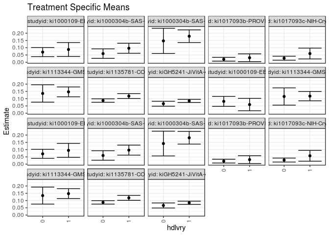

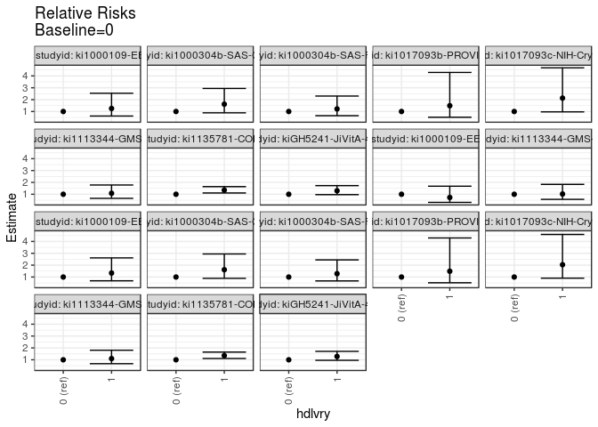

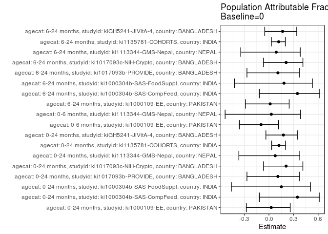

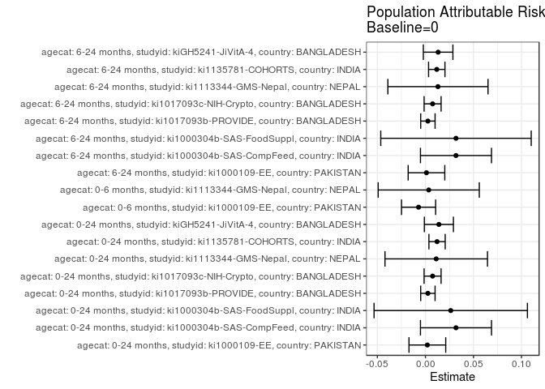

## Results Table

### Parameter: TSM

| agecat | studyid | country | intervention_level | baseline_level | estimate | ci_lower | ci_upper |
| --- | --- | --- | --- | --- | --- | --- | --- |
| 0-24 months | ki1000109-EE | PAKISTAN | 0 | NA | 0.0699830 | 0.0389042 | 0.1010619 |
| 0-24 months | ki1000109-EE | PAKISTAN | 1 | NA | 0.0876527 | 0.0396902 | 0.1356152 |
| 0-24 months | ki1000304b-SAS-CompFeed | INDIA | 0 | NA | 0.0596026 | 0.0268592 | 0.0923461 |
| 0-24 months | ki1000304b-SAS-CompFeed | INDIA | 1 | NA | 0.0963731 | 0.0619791 | 0.1307670 |
| 0-24 months | ki1000304b-SAS-FoodSuppl | INDIA | 0 | NA | 0.1469850 | 0.0601865 | 0.2337834 |
| 0-24 months | ki1000304b-SAS-FoodSuppl | INDIA | 1 | NA | 0.1790805 | 0.1356323 | 0.2225288 |
| 0-24 months | ki1017093b-PROVIDE | BANGLADESH | 0 | NA | 0.0208768 | 0.0080632 | 0.0336904 |
| 0-24 months | ki1017093b-PROVIDE | BANGLADESH | 1 | NA | 0.0310559 | 0.0042398 | 0.0578720 |
| 0-24 months | ki1017093c-NIH-Crypto | BANGLADESH | 0 | NA | 0.0281558 | 0.0145041 | 0.0418074 |
| 0-24 months | ki1017093c-NIH-Crypto | BANGLADESH | 1 | NA | 0.0599205 | 0.0226780 | 0.0971631 |
| 0-24 months | ki1113344-GMS-Nepal | NEPAL | 0 | NA | 0.1357607 | 0.0761270 | 0.1953944 |
| 0-24 months | ki1113344-GMS-Nepal | NEPAL | 1 | NA | 0.1467459 | 0.1128738 | 0.1806179 |
| 0-24 months | ki1135781-COHORTS | INDIA | 0 | NA | 0.0871022 | 0.0753498 | 0.0988546 |
| 0-24 months | ki1135781-COHORTS | INDIA | 1 | NA | 0.1175315 | 0.1006528 | 0.1344101 |
| 0-24 months | kiGH5241-JiVitA-4 | BANGLADESH | 0 | NA | 0.0652925 | 0.0482754 | 0.0823096 |
| 0-24 months | kiGH5241-JiVitA-4 | BANGLADESH | 1 | NA | 0.0844404 | 0.0734767 | 0.0954041 |
| 0-6 months | ki1000109-EE | PAKISTAN | 0 | NA | 0.0813008 | 0.0471019 | 0.1154997 |
| 0-6 months | ki1000109-EE | PAKISTAN | 1 | NA | 0.0593220 | 0.0166412 | 0.1020029 |
| 0-6 months | ki1113344-GMS-Nepal | NEPAL | 0 | NA | 0.1149001 | 0.0557187 | 0.1740816 |
| 0-6 months | ki1113344-GMS-Nepal | NEPAL | 1 | NA | 0.1174466 | 0.0853128 | 0.1495804 |
| 6-24 months | ki1000109-EE | PAKISTAN | 0 | NA | 0.0709060 | 0.0398189 | 0.1019931 |
| 6-24 months | ki1000109-EE | PAKISTAN | 1 | NA | 0.0945918 | 0.0466645 | 0.1425190 |
| 6-24 months | ki1000304b-SAS-CompFeed | INDIA | 0 | NA | 0.0596026 | 0.0268592 | 0.0923461 |
| 6-24 months | ki1000304b-SAS-CompFeed | INDIA | 1 | NA | 0.0963731 | 0.0619791 | 0.1307670 |
| 6-24 months | ki1000304b-SAS-FoodSuppl | INDIA | 0 | NA | 0.1415274 | 0.0563819 | 0.2266730 |
| 6-24 months | ki1000304b-SAS-FoodSuppl | INDIA | 1 | NA | 0.1813192 | 0.1376069 | 0.2250315 |
| 6-24 months | ki1017093b-PROVIDE | BANGLADESH | 0 | NA | 0.0208768 | 0.0080632 | 0.0336904 |
| 6-24 months | ki1017093b-PROVIDE | BANGLADESH | 1 | NA | 0.0310559 | 0.0042398 | 0.0578720 |
| 6-24 months | ki1017093c-NIH-Crypto | BANGLADESH | 0 | NA | 0.0281486 | 0.0144767 | 0.0418205 |
| 6-24 months | ki1017093c-NIH-Crypto | BANGLADESH | 1 | NA | 0.0573456 | 0.0200632 | 0.0946281 |
| 6-24 months | ki1113344-GMS-Nepal | NEPAL | 0 | NA | 0.1339821 | 0.0755743 | 0.1923899 |
| 6-24 months | ki1113344-GMS-Nepal | NEPAL | 1 | NA | 0.1474954 | 0.1134145 | 0.1815762 |
| 6-24 months | ki1135781-COHORTS | INDIA | 0 | NA | 0.0874207 | 0.0755791 | 0.0992623 |
| 6-24 months | ki1135781-COHORTS | INDIA | 1 | NA | 0.1183394 | 0.1013008 | 0.1353781 |
| 6-24 months | kiGH5241-JiVitA-4 | BANGLADESH | 0 | NA | 0.0660914 | 0.0487887 | 0.0833940 |
| 6-24 months | kiGH5241-JiVitA-4 | BANGLADESH | 1 | NA | 0.0844963 | 0.0733628 | 0.0956297 |

### Parameter: E(Y)

| agecat | studyid | country | intervention_level | baseline_level | estimate | ci_lower | ci_upper |
| --- | --- | --- | --- | --- | --- | --- | --- |
| 0-24 months | ki1000109-EE | PAKISTAN | NA | NA | 0.0720000 | 0.0458029 | 0.0981971 |
| 0-24 months | ki1000304b-SAS-CompFeed | INDIA | NA | NA | 0.0913978 | 0.0593363 | 0.1234594 |
| 0-24 months | ki1000304b-SAS-FoodSuppl | INDIA | NA | NA | 0.1733333 | 0.1349698 | 0.2116969 |
| 0-24 months | ki1017093b-PROVIDE | BANGLADESH | NA | NA | 0.0234375 | 0.0117074 | 0.0351676 |
| 0-24 months | ki1017093c-NIH-Crypto | BANGLADESH | NA | NA | 0.0356164 | 0.0221630 | 0.0490699 |
| 0-24 months | ki1113344-GMS-Nepal | NEPAL | NA | NA | 0.1470054 | 0.1174112 | 0.1765996 |
| 0-24 months | ki1135781-COHORTS | INDIA | NA | NA | 0.0992114 | 0.0898650 | 0.1085578 |
| 0-24 months | kiGH5241-JiVitA-4 | BANGLADESH | NA | NA | 0.0793041 | 0.0701363 | 0.0884719 |
| 0-6 months | ki1000109-EE | PAKISTAN | NA | NA | 0.0741758 | 0.0472177 | 0.1011340 |
| 0-6 months | ki1113344-GMS-Nepal | NEPAL | NA | NA | 0.1183432 | 0.0901986 | 0.1464877 |
| 6-24 months | ki1000109-EE | PAKISTAN | NA | NA | 0.0720000 | 0.0458029 | 0.0981971 |
| 6-24 months | ki1000304b-SAS-CompFeed | INDIA | NA | NA | 0.0913978 | 0.0593363 | 0.1234594 |
| 6-24 months | ki1000304b-SAS-FoodSuppl | INDIA | NA | NA | 0.1733333 | 0.1349698 | 0.2116969 |
| 6-24 months | ki1017093b-PROVIDE | BANGLADESH | NA | NA | 0.0234375 | 0.0117074 | 0.0351676 |
| 6-24 months | ki1017093c-NIH-Crypto | BANGLADESH | NA | NA | 0.0356164 | 0.0221630 | 0.0490699 |
| 6-24 months | ki1113344-GMS-Nepal | NEPAL | NA | NA | 0.1470054 | 0.1174112 | 0.1765996 |
| 6-24 months | ki1135781-COHORTS | INDIA | NA | NA | 0.0992114 | 0.0898650 | 0.1085578 |
| 6-24 months | kiGH5241-JiVitA-4 | BANGLADESH | NA | NA | 0.0793041 | 0.0701363 | 0.0884719 |

### Parameter: RR

| agecat | studyid | country | intervention_level | baseline_level | estimate | ci_lower | ci_upper |
| --- | --- | --- | --- | --- | --- | --- | --- |
| 0-24 months | ki1000109-EE | PAKISTAN | 0 | 0 | 1.000000 | 1.0000000 | 1.000000 |
| 0-24 months | ki1000109-EE | PAKISTAN | 1 | 0 | 1.252485 | 0.6181739 | 2.537665 |
| 0-24 months | ki1000304b-SAS-CompFeed | INDIA | 0 | 0 | 1.000000 | 1.0000000 | 1.000000 |
| 0-24 months | ki1000304b-SAS-CompFeed | INDIA | 1 | 0 | 1.616926 | 0.8882404 | 2.943402 |
| 0-24 months | ki1000304b-SAS-FoodSuppl | INDIA | 0 | 0 | 1.000000 | 1.0000000 | 1.000000 |
| 0-24 months | ki1000304b-SAS-FoodSuppl | INDIA | 1 | 0 | 1.218360 | 0.6444851 | 2.303234 |
| 0-24 months | ki1017093b-PROVIDE | BANGLADESH | 0 | 0 | 1.000000 | 1.0000000 | 1.000000 |
| 0-24 months | ki1017093b-PROVIDE | BANGLADESH | 1 | 0 | 1.487578 | 0.5156933 | 4.291091 |
| 0-24 months | ki1017093c-NIH-Crypto | BANGLADESH | 0 | 0 | 1.000000 | 1.0000000 | 1.000000 |
| 0-24 months | ki1017093c-NIH-Crypto | BANGLADESH | 1 | 0 | 2.128179 | 0.9672335 | 4.682579 |
| 0-24 months | ki1113344-GMS-Nepal | NEPAL | 0 | 0 | 1.000000 | 1.0000000 | 1.000000 |
| 0-24 months | ki1113344-GMS-Nepal | NEPAL | 1 | 0 | 1.080916 | 0.6560832 | 1.780839 |
| 0-24 months | ki1135781-COHORTS | INDIA | 0 | 0 | 1.000000 | 1.0000000 | 1.000000 |
| 0-24 months | ki1135781-COHORTS | INDIA | 1 | 0 | 1.349351 | 1.1082391 | 1.642921 |
| 0-24 months | kiGH5241-JiVitA-4 | BANGLADESH | 0 | 0 | 1.000000 | 1.0000000 | 1.000000 |
| 0-24 months | kiGH5241-JiVitA-4 | BANGLADESH | 1 | 0 | 1.293262 | 0.9681390 | 1.727570 |
| 0-6 months | ki1000109-EE | PAKISTAN | 0 | 0 | 1.000000 | 1.0000000 | 1.000000 |
| 0-6 months | ki1000109-EE | PAKISTAN | 1 | 0 | 0.729661 | 0.3170816 | 1.679080 |
| 0-6 months | ki1113344-GMS-Nepal | NEPAL | 0 | 0 | 1.000000 | 1.0000000 | 1.000000 |
| 0-6 months | ki1113344-GMS-Nepal | NEPAL | 1 | 0 | 1.022163 | 0.5701529 | 1.832520 |
| 6-24 months | ki1000109-EE | PAKISTAN | 0 | 0 | 1.000000 | 1.0000000 | 1.000000 |
| 6-24 months | ki1000109-EE | PAKISTAN | 1 | 0 | 1.334045 | 0.6815644 | 2.611163 |
| 6-24 months | ki1000304b-SAS-CompFeed | INDIA | 0 | 0 | 1.000000 | 1.0000000 | 1.000000 |
| 6-24 months | ki1000304b-SAS-CompFeed | INDIA | 1 | 0 | 1.616926 | 0.8882404 | 2.943402 |
| 6-24 months | ki1000304b-SAS-FoodSuppl | INDIA | 0 | 0 | 1.000000 | 1.0000000 | 1.000000 |
| 6-24 months | ki1000304b-SAS-FoodSuppl | INDIA | 1 | 0 | 1.281160 | 0.6711763 | 2.445512 |
| 6-24 months | ki1017093b-PROVIDE | BANGLADESH | 0 | 0 | 1.000000 | 1.0000000 | 1.000000 |
| 6-24 months | ki1017093b-PROVIDE | BANGLADESH | 1 | 0 | 1.487578 | 0.5156933 | 4.291091 |
| 6-24 months | ki1017093c-NIH-Crypto | BANGLADESH | 0 | 0 | 1.000000 | 1.0000000 | 1.000000 |
| 6-24 months | ki1017093c-NIH-Crypto | BANGLADESH | 1 | 0 | 2.037247 | 0.9043602 | 4.589294 |
| 6-24 months | ki1113344-GMS-Nepal | NEPAL | 0 | 0 | 1.000000 | 1.0000000 | 1.000000 |
| 6-24 months | ki1113344-GMS-Nepal | NEPAL | 1 | 0 | 1.100859 | 0.6705134 | 1.807407 |
| 6-24 months | ki1135781-COHORTS | INDIA | 0 | 0 | 1.000000 | 1.0000000 | 1.000000 |
| 6-24 months | ki1135781-COHORTS | INDIA | 1 | 0 | 1.353677 | 1.1112481 | 1.648994 |
| 6-24 months | kiGH5241-JiVitA-4 | BANGLADESH | 0 | 0 | 1.000000 | 1.0000000 | 1.000000 |
| 6-24 months | kiGH5241-JiVitA-4 | BANGLADESH | 1 | 0 | 1.278477 | 0.9550536 | 1.711426 |

### Parameter: PAR

| agecat | studyid | country | intervention_level | baseline_level | estimate | ci_lower | ci_upper |
| --- | --- | --- | --- | --- | --- | --- | --- |
| 0-24 months | ki1000109-EE | PAKISTAN | 0 | NA | 0.0020170 | -0.0170929 | 0.0211268 |
| 0-24 months | ki1000304b-SAS-CompFeed | INDIA | 0 | NA | 0.0317952 | -0.0051651 | 0.0687555 |
| 0-24 months | ki1000304b-SAS-FoodSuppl | INDIA | 0 | NA | 0.0263484 | -0.0534607 | 0.1061574 |
| 0-24 months | ki1017093b-PROVIDE | BANGLADESH | 0 | NA | 0.0025607 | -0.0049237 | 0.0100450 |
| 0-24 months | ki1017093c-NIH-Crypto | BANGLADESH | 0 | NA | 0.0074607 | -0.0013819 | 0.0163032 |
| 0-24 months | ki1113344-GMS-Nepal | NEPAL | 0 | NA | 0.0112447 | -0.0420932 | 0.0645827 |
| 0-24 months | ki1135781-COHORTS | INDIA | 0 | NA | 0.0121092 | 0.0036418 | 0.0205766 |
| 0-24 months | kiGH5241-JiVitA-4 | BANGLADESH | 0 | NA | 0.0140116 | -0.0011159 | 0.0291390 |
| 0-6 months | ki1000109-EE | PAKISTAN | 0 | NA | -0.0071250 | -0.0248864 | 0.0106364 |
| 0-6 months | ki1113344-GMS-Nepal | NEPAL | 0 | NA | 0.0034431 | -0.0491769 | 0.0560630 |
| 6-24 months | ki1000109-EE | PAKISTAN | 0 | NA | 0.0010940 | -0.0179564 | 0.0201445 |
| 6-24 months | ki1000304b-SAS-CompFeed | INDIA | 0 | NA | 0.0317952 | -0.0051651 | 0.0687555 |
| 6-24 months | ki1000304b-SAS-FoodSuppl | INDIA | 0 | NA | 0.0318059 | -0.0464837 | 0.1100955 |
| 6-24 months | ki1017093b-PROVIDE | BANGLADESH | 0 | NA | 0.0025607 | -0.0049237 | 0.0100450 |
| 6-24 months | ki1017093c-NIH-Crypto | BANGLADESH | 0 | NA | 0.0074679 | -0.0013845 | 0.0163202 |
| 6-24 months | ki1113344-GMS-Nepal | NEPAL | 0 | NA | 0.0130234 | -0.0390831 | 0.0651298 |
| 6-24 months | ki1135781-COHORTS | INDIA | 0 | NA | 0.0117907 | 0.0032697 | 0.0203116 |
| 6-24 months | kiGH5241-JiVitA-4 | BANGLADESH | 0 | NA | 0.0132128 | -0.0021729 | 0.0285985 |

### Parameter: PAF

| agecat | studyid | country | intervention_level | baseline_level | estimate | ci_lower | ci_upper |
| --- | --- | --- | --- | --- | --- | --- | --- |
| 0-24 months | ki1000109-EE | PAKISTAN | 0 | NA | 0.0280134 | -0.2762866 | 0.2597604 |
| 0-24 months | ki1000304b-SAS-CompFeed | INDIA | 0 | NA | 0.3478769 | -0.1175046 | 0.6194516 |
| 0-24 months | ki1000304b-SAS-FoodSuppl | INDIA | 0 | NA | 0.1520099 | -0.4587012 | 0.5070359 |
| 0-24 months | ki1017093b-PROVIDE | BANGLADESH | 0 | NA | 0.1092554 | -0.2683734 | 0.3744540 |
| 0-24 months | ki1017093c-NIH-Crypto | BANGLADESH | 0 | NA | 0.2094726 | -0.0660478 | 0.4137846 |
| 0-24 months | ki1113344-GMS-Nepal | NEPAL | 0 | NA | 0.0764920 | -0.3672351 | 0.3762104 |
| 0-24 months | ki1135781-COHORTS | INDIA | 0 | NA | 0.1220545 | 0.0332465 | 0.2027044 |
| 0-24 months | kiGH5241-JiVitA-4 | BANGLADESH | 0 | NA | 0.1766819 | -0.0371920 | 0.3464539 |
| 0-6 months | ki1000109-EE | PAKISTAN | 0 | NA | -0.0960554 | -0.3610553 | 0.1173486 |
| 0-6 months | ki1113344-GMS-Nepal | NEPAL | 0 | NA | 0.0290939 | -0.5347260 | 0.3857804 |
| 6-24 months | ki1000109-EE | PAKISTAN | 0 | NA | 0.0151946 | -0.2878231 | 0.2469139 |
| 6-24 months | ki1000304b-SAS-CompFeed | INDIA | 0 | NA | 0.3478769 | -0.1175046 | 0.6194516 |
| 6-24 months | ki1000304b-SAS-FoodSuppl | INDIA | 0 | NA | 0.1834955 | -0.4187563 | 0.5300957 |
| 6-24 months | ki1017093b-PROVIDE | BANGLADESH | 0 | NA | 0.1092554 | -0.2683734 | 0.3744540 |
| 6-24 months | ki1017093c-NIH-Crypto | BANGLADESH | 0 | NA | 0.2096743 | -0.0664264 | 0.4142919 |
| 6-24 months | ki1113344-GMS-Nepal | NEPAL | 0 | NA | 0.0885910 | -0.3437926 | 0.3818493 |
| 6-24 months | ki1135781-COHORTS | INDIA | 0 | NA | 0.1188439 | 0.0293594 | 0.2000787 |
| 6-24 months | kiGH5241-JiVitA-4 | BANGLADESH | 0 | NA | 0.1666088 | -0.0512046 | 0.3392904 |